# Medicare - Covered Charges vs Total Payments

Hailu Teju

July 1, 2017

## Project 1 - Reproducible Research

**Instructions:**

Look at a subset of a United States medical expenditures dataset with information on cost for different medical conditions and in different ares of the country.

You should do the following:

1. Make a plot that answers the question: what is the relationship between mean covered charges (Avereage.Covered.Charges) and mean total payments (Average.Total.Payments) in New York?
2. Make a plot (possibly multi-panel) that answers the question: how does the relationship between mean covered charges and mean total payments vary by medical condition (DRG.Definition) and the state in which care was received (Provider.State)?

**Use only the ggplot2 graphics system (not base R or lattice) to make your figure.**

Please submit (1) R code that creates you plots, (2) a single pdf for plot 1 and (3) a single pdf for plot 2. You will be graded on whether you answered the questions and a number of features describing the clarity of the plots including axis labels, figure legends, figure captions, and plots. For guidelines on how to create production quality plots see Chapter 10 of [Elements of Data Analytics Style](https://leanpub.com/datastyle).

To make the plots use the data in the attached .csv file. These data are a processed version of the data from the site:https://data.cms.gov/Medicare/Inpatient-Prospective-Payment-System-IPPS-Provider/97k6-zzx3.

```
'data.frame':   6401 obs. of  12 variables:
 $ DRG.Definition                      : Factor w/ 6 levels "194 - SIMPLE PNEUMONIA & PLEURISY W CC",..: 1 1 1 1 1 1 1 1 1 1 ...
 $ Provider.Id                         : int  50242 100061 100062 100181 100183 100187 100314 100316 50002 50006 ...
 $ Provider.Name                       : Factor w/ 1124 levels "ABILENE REGIONAL MEDICAL CENTER",..: 229 588 637 489 190 711 1096 705 963 937 ...
 $ Provider.Street.Address             : Factor w/ 1149 levels "1 HOSPITAL DRIVE",..: 284 674 265 982 611 405 1107 237 551 543 ...
 $ Provider.City                       : Factor w/ 763 levels "ABILENE","ABINGTON",..: 611 422 480 645 141 290 422 502 282 210 ...
 $ Provider.State                      : Factor w/ 6 levels "CA","FL","IL",..: 1 2 2 2 2 2 2 2 1 1 ...
 $ Provider.Zip.Code                   : int  95065 33133 34474 33143 33134 33016 33196 32907 94545 95501 ...
 $ Hospital.Referral.Region.Description: Factor w/ 118 levels "AL - Dothan",..: 24 37 38 37 37 37 37 39 4 14 ...
 $ Total.Discharges                    : int  96 32 96 74 35 54 13 11 28 44 ...
 $ Average.Covered.Charges             : num  60387 33432 25887 39933 74303 ...
 $ Average.Total.Payments              : num  9175 7389 5420 8326 8242 ...
 $ Average.Medicare.Payments           : num  8250 6415 4542 7616 7097 ...
```

## Solution

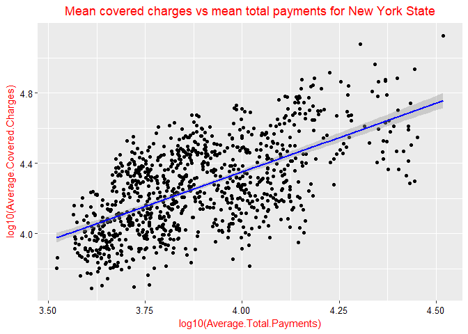

```r
library(dplyr)
library(ggplot2)

paymNY <- payments %>% filter(Provider.State == 'NY')


g <- ggplot(paymNY, aes(log10(Average.Total.Payments),
                        log10(Average.Covered.Charges)))
g <- g + geom_point() + stat_smooth(method = 'lm', color='blue')

g <- g + ggtitle("Mean covered charges vs mean total payments for New York State")

g <- g + theme(axis.text=element_text(color="black", size=10))
g <- g + theme(axis.title.x=element_text(color="red", size=11),
               axis.title.y=element_text(color="red", size=11),
               plot.title=element_text(color="red", hjust=0.5))

print(g)
```

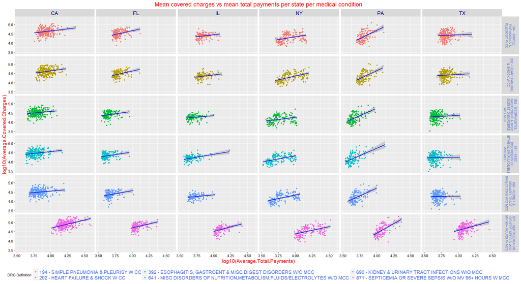

```r
swr = function(string, nwrap=20) {
        paste(strwrap(string, width=nwrap), collapse="\n")
}
swr = Vectorize(swr)


g <- ggplot(payments, aes(log10(Average.Total.Payments),
                        log10(Average.Covered.Charges)))
g <- g + geom_point() + stat_smooth(method = 'lm', color='blue')
g <- g + facet_grid(swr(DRG.Definition) ~ Provider.State) + aes(color=DRG.Definition)

g <- g + ggtitle("Mean covered charges vs mean total payments per state per medical condition")

g <- g + theme(axis.text=element_text(color="black", size=11))
g <- g + theme(axis.title.x=element_text(color="red", size=16),
               axis.title.y=element_text(color="red", size=16),
               plot.title=element_text(color="red", size = 18, hjust=0.5))

g <- g + theme(legend.position = 'bottom', legend.text=element_text(color='royalblue', size=14))
g <- g + theme(strip.text.x = element_text(size = 16, color='darkblue'))
g <- g + theme(strip.text.y = element_text(size = 10, color='royalblue'))


print(g)
```